# 00_EDA

```python
import numpy as np  # operaciones con arrays y numéricas
import pandas as pd # manipulación de dataframes
import matplotlib.pyplot as plt # visualizaciones
import seaborn as sns # visualizaciones
import matplotlib as mpl # para los estilos de las visualizaciones
import pandas_profiling as pp # libreria de EDA comentada en clase
```

```python
estudiantes = pd.read_csv('../data/01_raw/student-por.csv') # lecutra de los datos
```

```python
# pp.ProfileReport(estudiantes) lo dejo comentado porque me salta error
# he buscado información y al parecer hay problemas con la ultima versión de pandaas. Pefiero
# no "desactualizar" pandas, por si acaso. Haré el EDA de manera tradicional
```

```python
estudiantes.shape # 649 observaciones, 33 variables
```

```
(649, 33)
```

```python
estudiantes.info()
```

```
<class 'pandas.core.frame.DataFrame'>
RangeIndex: 649 entries, 0 to 648
Data columns (total 33 columns):
 #   Column      Non-Null Count  Dtype
---  ------      --------------  -----
 0   school      649 non-null    object
 1   sex         649 non-null    object
 2   age         649 non-null    int64
 3   address     649 non-null    object
 4   famsize     649 non-null    object
 5   Pstatus     649 non-null    object
 6   Medu        649 non-null    int64
 7   Fedu        649 non-null    int64
 8   Mjob        649 non-null    object
 9   Fjob        649 non-null    object
```

[output cut: 25 more lines]

### Glosario de términos

```python
# Examen de NA's
estudiantes.isna().sum() # no hay valores NA en el dataset
```

```
school        0
sex           0
age           0
address       0
famsize       0
Pstatus       0
Medu          0
Fedu          0
Mjob          0
Fjob          0
reason        0
guardian      0
traveltime    0
studytime     0
failures      0
schoolsup     0
famsup        0
paid          0
activities    0
nursery       0
higher        0
internet      0
romantic      0
famrel        0
freetime      0
goout         0
Dalc          0
Walc          0
health        0
absences      0
G1            0
G2            0
G3            0
dtype: int64
```

```python
# Transformo las notas y  sobre 10, que estan sobre 20 y sobre 10 se entienden mejor
estudiantes.G1 = estudiantes.G1 / 20 * 10
estudiantes.G2 = estudiantes.G2 / 20 * 10
estudiantes.G3 = estudiantes.G3 / 20 * 10
```

```python
# Creo un nuevo dataframe que contenga solo las variables numéricas, para estudiar las
# correlaciones y hacer cálculos con ellas.

estudiantes_variables_numericas = estudiantes.loc[:, ['age', 'traveltime', 'studytime', 'absences',
                                                      'G1' , 'G2', 'G3' , 'failures']]
```

```python
estudiantes_variables_numericas.describe()
```

|  | age | traveltime | studytime | absences | G1 | G2 | G3 | failures |
| --- | --- | --- | --- | --- | --- | --- | --- | --- |
| count | 649.000000 | 649.000000 | 649.000000 | 649.000000 | 649.000000 | 649.000000 | 649.000000 | 649.000000 |
| mean | 16.744222 | 1.568567 | 1.930663 | 3.659476 | 5.699538 | 5.785054 | 5.953005 | 0.221880 |
| std | 1.218138 | 0.748660 | 0.829510 | 4.640759 | 1.372633 | 1.456819 | 1.615328 | 0.593235 |
| min | 15.000000 | 1.000000 | 1.000000 | 0.000000 | 0.000000 | 0.000000 | 0.000000 | 0.000000 |
| 25% | 16.000000 | 1.000000 | 1.000000 | 0.000000 | 5.000000 | 5.000000 | 5.000000 | 0.000000 |
| 50% | 17.000000 | 1.000000 | 2.000000 | 2.000000 | 5.500000 | 5.500000 | 6.000000 | 0.000000 |
| 75% | 18.000000 | 2.000000 | 2.000000 | 6.000000 | 6.500000 | 6.500000 | 7.000000 | 0.000000 |
| max | 22.000000 | 4.000000 | 4.000000 | 32.000000 | 9.500000 | 9.500000 | 9.500000 | 3.000000 |

Se trata de un conjunto de 649 estudiantes, de edades entre los 15 y 22 años. La nota media del grupo para el curso (3 trimestres) es de aproximadamente 5.8 sobre 10.

El dataset contiene múltiples datos acerca de las características de los estudiantes, así como sus notas medias, todos recogidos mediante encuesta. Puede ser interesante graficar distintas variables, como el sexo, la ocupación de los padres, o el consumo de alcohol en relación con las notas medias de los alumnos

### Correlaciones: variables numéricas

```python
# Guardo los nombres de las variables para poder añadirlas a los ejes del grafico
nombres_variables = ['age', 'traveltime', 'studytime', 'absences', 'G1' , 'G2', 'G3' , 'failures']

correlaciones = np.corrcoef(estudiantes[nombres_variables].values.T) # calculo las correlaciones
correlaciones
f, ax = plt.subplots(figsize=(12, 7))

ax = sns.heatmap(
    correlaciones,
    annot=True,  # para que muestre el valor de las correlaciones
    yticklabels=nombres_variables, # nombres de cada eje
    xticklabels=nombres_variables,
    linewidths=.5, # separación entre cuadros
    cmap="YlGnBu") # escala de colores (yellow, green blue)
```

[output not shown]

Las variables de las notas G1 2 y 3 presetan alta correlacion entre ellas. El número de suspensos presenta correlación negativa con las notas, es decir, a mayor número de suspensos, peor nota

### Variable sexo

```python
mpl.style.use('ggplot') # estilo de las visualizaciones
sns.set_palette('icefire') # paleta de colores
```

```python
# Sexo
g = sns.catplot(x="sex",
            kind="count",
            data=estudiantes,
           palette=['lightpink', 'aqua'],
           edgecolor='black')
plt.title("Sexo de los estudiantes")
g.set(xlabel=None,
      ylabel='Nº de estudiantes');
# si el grafico genera un objeto tipo facet (como este), hay que usar esta sintaxis para los label
```

[output not shown]

El sexo femenino es claramente más numeroso

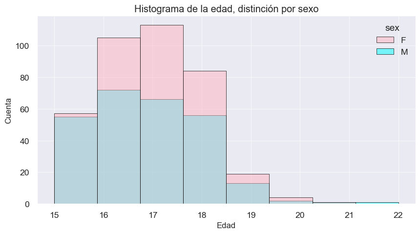

```python
# Histograma del sexo y la edad

f, ax = plt.subplots(figsize=(10, 5))

color_sexo = {'F': 'lightpink',
             'M': 'aqua'} # diccionario para asignar los colores

g = sns.histplot(x='age',
                  data=estudiantes,
                  hue='sex',
                 edgecolor='black',
                 bins=8,  # particiones de los datos
                 palette=color_sexo)

g.set_title("Histograma de la edad, distinción por sexo")
g.set_xlabel("Edad")
g.set_ylabel("Cuenta");
```

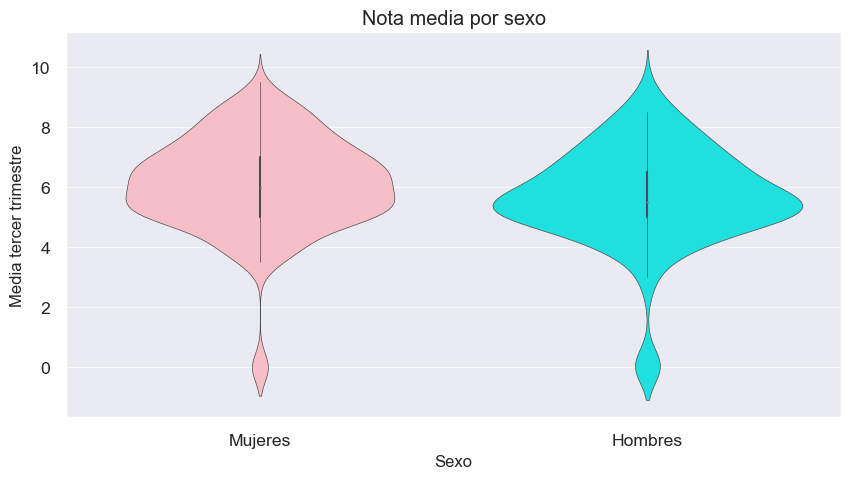

```python
# Nota media por sexo
f, plt.subplots(figsize=(10, 5))

g = sns.violinplot(
    x='sex',
    y='G3',
    data=estudiantes,
    palette=color_sexo,
    linewidth=.5)

g.set_title('Nota media por sexo')
g.set_xticklabels(['Mujeres', 'Hombres']) # para cambiar el pie de cada grafico (antes era F, M)
g.set_xlabel('Sexo')
g.set_ylabel('Media tercer trimestre');
```

No se aprecian diferencias significativas en la nota media en función del sexo

### Suspensos en función del sexo

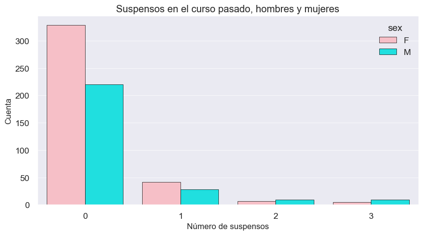

```python
f, plt.subplots(figsize=(10, 5))

g = sns.countplot(
    x='failures',
    data=estudiantes,
    hue="sex",
    palette=color_sexo,
    edgecolor='black');
g.set_title('Suspensos en el curso pasado, hombres y mujeres')
g.set_xlabel('Número de suspensos')
g.set_ylabel('Cuenta');
```

Hay mas suspensos femeninos que masculinos, pero hay que tener en cuenta que la mayoria de los estudiates del dataset son mujeres

### Consumo de alcohol

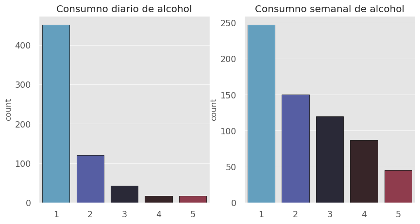

```python
f, axs=plt.subplots(ncols=2, figsize = (10, 5))

# Consumo diario
g1 = sns.countplot(x='Dalc',
             data=estudiantes,
                   ax=axs[0],
                  edgecolor='black')
g1.set_xlabel(None)
g1.set_title('Consumno diario de alcohol')

g2 = sns.countplot(x='Walc',
             data=estudiantes,
                   ax=axs[1],
                  edgecolor='black')
g2.set_xlabel(None)
g2.set_title('Consumno semanal de alcohol');
```

Se aprecia como el consumo semanal parece más elevado que el diario, puesto que las columnas que representan mayor consumo tienen más valor. Es coherente puesto que los jóvenes acostumbran a consumir alcohol los fines de semana, y la variable semanal esta recogiendo este consumo

### Distribución de las notas para cada nivel de consumo

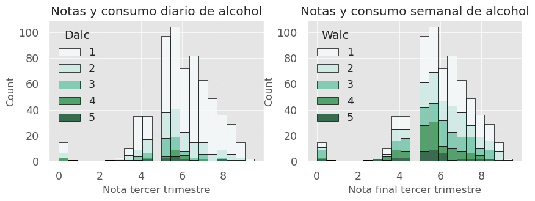

```python
# Nota media y consmumo de alcohol diario
f, axs=plt.subplots(ncols=2, figsize=(10, 3))

g = sns.histplot(
    x='G3',  # utilizo G3 porque es la que mas desviación tiene
    data=estudiantes,
    hue='Dalc', # distinción por consumo de alcohol diario
    multiple="stack", # grafico apilado
    palette='BuGn', # color del relleno
    edgecolor='black', # color del borde de las barras
    linewidth=.5,  # grosor del borde de las barras
    ax=axs[0]) # posicion del primer plot

g.set_title('Notas y consumo diario de alcohol')
g.set_xlabel('Nota tercer trimestre')

# Nota media y consmumo de alcohol semanal
g = sns.histplot(
    x='G3',
    data=estudiantes,
    hue='Walc',
    multiple='stack',
    palette='BuGn',
    edgecolor='black',
    linewidth=.5,
    ax=axs[1]) # posicion del segundo plot

g.set_title('Notas y consumo semanal de alcohol')
g.set_xlabel('Nota final tercer trimestre');
```

La distribucuion de las notas es mas o menos similar en cuanto a forma, aunque hay mas valores correspondientes a las categorias de consumo de alcohol mas bajas

### ¿Consumen más alcohol (semanal) los hombres o las mujeres?

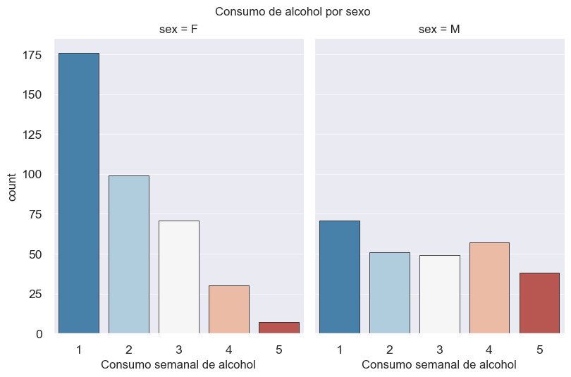

```python
g = sns.catplot(
    x='Walc',
    data=estudiantes,
    col='sex',
    kind='count',
    palette='RdBu_r',
    edgecolor='black',
    height=5, aspect=.8) # modifican el tamaño

g.fig.suptitle('Consumo de alcohol por sexo', y=1.02)
g.set(
    xlabel='Consumo semanal de alcohol');
```

Los datos muestran que los hombres consumen más alcohol, puesto que las barras de más consumo (4 y 5) tienen mayor frecuencia en los hombres que en las mujeres, pese a ser estos el grupo más pequeño del dataset

### Influencia de las horas de estudio en la nota final

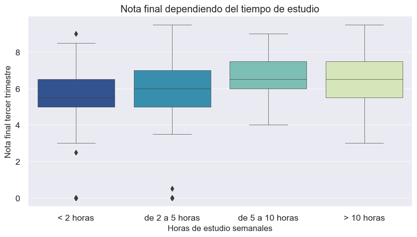

```python
# Creo una variable que descodifique la variable de estudio, que tomaba valores de 1 a 5 en funcion de las horas
for col in [estudiantes]:
    col.loc[col['studytime'] == 1 , 'study_time'] = '< 2 horas'
    col.loc[col['studytime'] == 2 , 'study_time'] = 'de 2 a 5 horas'
    col.loc[col['studytime'] == 3, 'study_time'] = 'de 5 a 10 horas'
    col.loc[col['studytime'] == 4, 'study_time'] = '> 10 horas'

# Con esta nueva variable ya puedo hace el plot por categorias.

# Creo una lista de las cuatro categorias ordenadas
orden = ['< 2 horas', 'de 2 a 5 horas', 'de 5 a 10 horas', '> 10 horas']

f, plt.subplots(figsize=(10, 5))
sns.boxplot(
    x='study_time',
    y='G3',
    data = estudiantes,
    palette = 'YlGnBu_r',
    linewidth=.5,
    order=orden)

plt.title('Nota final dependiendo del tiempo de estudio')
plt.xlabel('Horas de estudio semanales')
plt.ylabel('Nota final tercer trimestre');
```

Se aprecia que aquellos estudiantes que estudian más horas semanales obtienen mayores notas medias. Esta tencencia se rompe ligeramente con el grupo de aquellos que estudian más de 10 horas a la semana, quizá sea un grupo al que le cueste más interiorizar los conocimientos. No obstante, esto son datos semanales. Hay que tener en cuenta que el número de horas requeridas para un nivel de nota media en detrminada asignatura depende mucho de la persona, y de la asignatura. Por ejemplo, para nuestro máster enn Data Science, 2 a 5 horas a la semana parece muy poco tiempo de estudio.

### ¿Cuántos estudiantes están en una relación? ¿Afecta a su rendimiento académico?

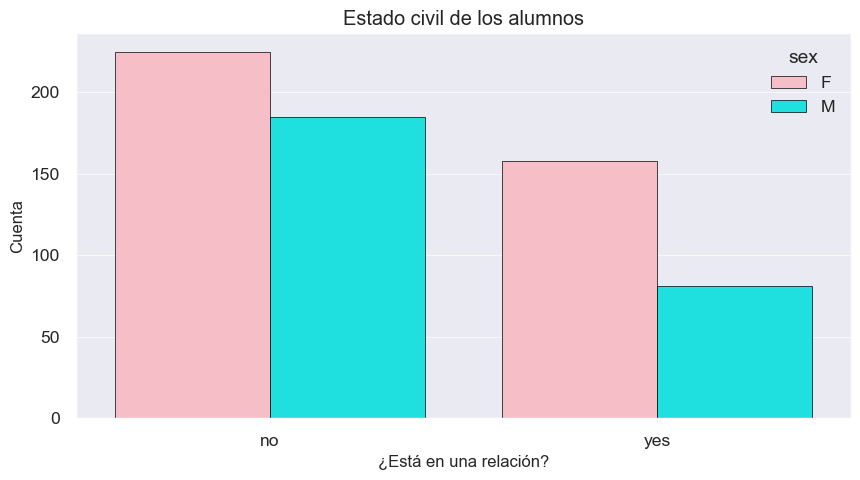

```python
f, plt.subplots(figsize=(10, 5))

g = sns.countplot(
    x='romantic',
    data=estudiantes,
    edgecolor='black',
    hue='sex',
    palette=color_sexo);

g.set_title('Estado civil de los alumnos')
g.set_xlabel('¿Está en una relación?')
g.set_ylabel('Cuenta');
```

La mayoría de los alumnos no están en una relación

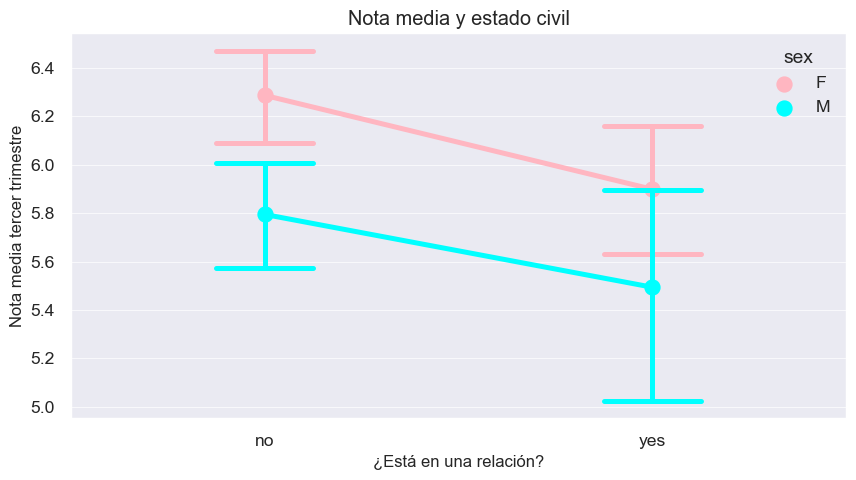

```python
# Grafico de intervalos de confianza para la media

f, plt.subplots(figsize=(10, 5))

g = sns.pointplot(
    x='romantic',
    y='G3',
    data=estudiantes,
    hue='sex',
    palette=color_sexo,
    capsize=0.25)

g.set_title('Nota media y estado civil')
g.set_xlabel('¿Está en una relación?')
g.set_ylabel('Nota media tercer trimestre');
```

Las notas medias son algo inferiores para los alumnos que están en una relación, tanto como para hombres como para mujeres. Sin embargo, si se tiene en cuenta el intervalo de confianza, las medias son estadísticamente iguales, tanto si tiene una relación como no.

### ¿Como se distribuyen las ausencias a clase respecto al consumo de alcohol?

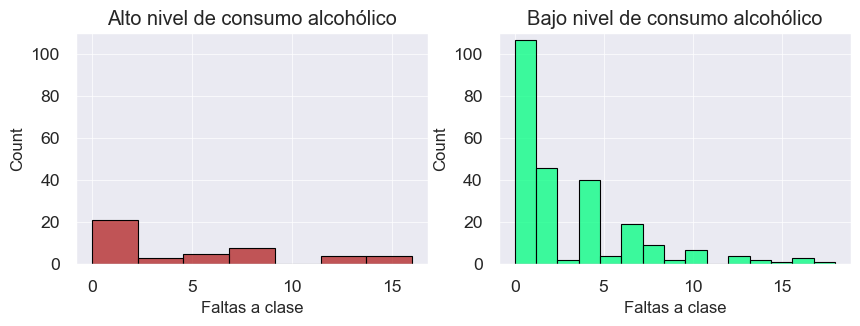

```python
f, axs=plt.subplots(ncols=2, figsize=(10, 3))

# El grafico para ausencias y mayor nivel de consumo alcohólico semanal (valor de 5 en el dataset)
g1 = sns.histplot(
    estudiantes[(estudiantes.Walc == 5)]["absences"], # ausencias de los que mas beben(Walc == 5)
    color='firebrick',
    edgecolor='black',
    linewidth=.8,
    ax=axs[0]) # posicion del plot en el output

g1.set_title('Alto nivel de consumo alcohólico')
g1.set_xlabel('Faltas a clase')
g1.set_ylim(0, 110) # hago esto para que tengan el mismo eje y, y poder compararlos

# Mismo grafico para ausencias  pero menor nivel de consumo alcohólico semanal (valor de 1 en el dataset)
g2 = sns.histplot(
    estudiantes[(estudiantes.Walc == 1)]["absences"], # ausencias de los que menos beben(Walc == 1)
    color='springgreen',
    edgecolor='black',
    linewidth=.8,
    ax=axs[1])  # posicion del plot en el output

g2.set_title('Bajo nivel de consumo alcohólico')
g2.set_xlabel('Faltas a clase')
g2.set_ylim(0, 110);
```

### Influencia del aclohol en la nota final

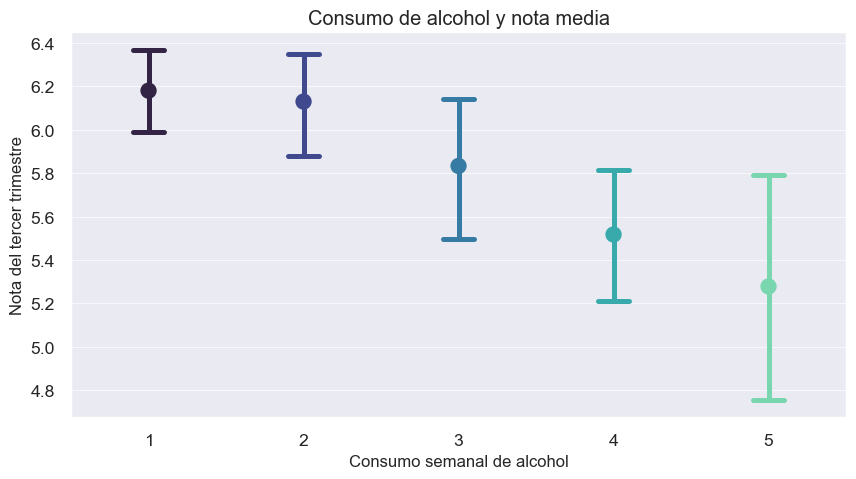

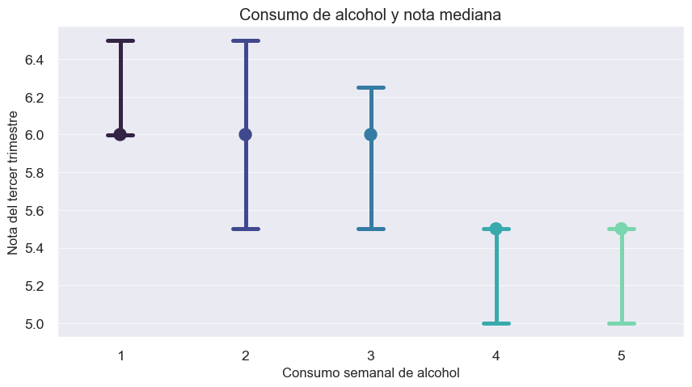

```python
# Utilizando la media como estimador
f, plt.subplots(figsize=(10, 5))

g1 = sns.pointplot(
    x="Walc",
    y="G3",
    palette="mako",
    edgecolor='black',
    capsize=0.2,
    data=estudiantes)

g1.set_title('Consumo de alcohol y nota media')
g1.set_xlabel('Consumo semanal de alcohol')
g1.set_ylabel('Nota del tercer trimestre');



# Utilizando la mediana como estimador
f, plt.subplots(figsize=(10, 5))

g2 = sns.pointplot(
    x="Walc",
    y="G3",
    estimator=np.median,
    palette="mako",
    edgecolor='black',
    capsize=0.2, # el "cierre" del intervalo de confianza
    data=estudiantes)

g2.set_title('Consumo de alcohol y nota mediana')
g2.set_xlabel('Consumo semanal de alcohol')
g2.set_ylabel('Nota del tercer trimestre');
```

Hay un efecto negativo en el consumo de alcohol y la nota media de los alumnos, como cabría esperar. Los puntos señalan la media, y desvelan la caida a medida que aumenta el consumo de alcohol. Se incluye también la representación utilizando como estimador la mediana, puesto que es un estadístico robusto frente a outliers. También disminuye

### Nota media y clases particulares

[figure not shown]

```python
f, plt.subplots(figsize=(10, 5))

g = sns.pointplot(
    x='paid', # variable de las clases particulares
    y='G3',
    palette='mako',
    capsize=0.2,
    data=estudiantes)

g.set_('Nota media y clases particulares')
g.set_xlabel('Clases particulates')
g.set_ylabel('Nota del tercer trimestre');
```

Sorprendentemente, los alumnos que reciben clases particulares tienen una nota media de aproximadamente medio punto inferior a los que no reciben ese tipo de soporte. No obstante, el intervalo de confianza para el segundo grupo es tan amplio que habrá puntos en los que la media del segundo grupo coincida con las del primero, o incluso lo supere

### Nota media y profesión del padre

```python
estudiantes.Fjob.unique(), estudiantes.Mjob.unique()
```

```
(array(['teacher', 'other', 'services', 'health', 'at_home'], dtype=object),
 array(['at_home', 'health', 'other', 'services', 'teacher'], dtype=object))
```

Entre las profesiones de los padres, se encuentra la de profesor. Quizá esto tenga impactos en las notas de los alumnos

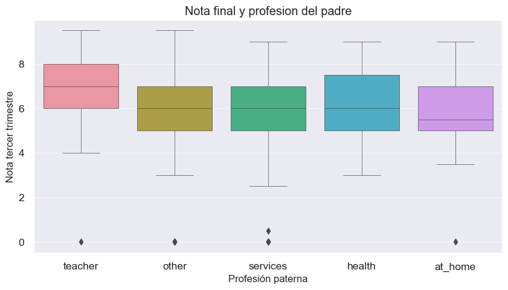

```python
# Profesion del padre
plt.figure(figsize=(10,5))


g = sns.boxplot(
    x='Fjob',
    y='G3',
    data = estudiantes,
    linewidth=.5);

g.set_title('Nota final y profesion del padre')
g.set_xlabel('Profesión paterna')
g.set_ylabel('Nota tercer trimestre');
```

Los estudiatnes cuyo padre es profesor tienen mayor nota media que el resto de grupos, algo coherente con el hecho de que quizá sus padres estén mejor formados sobre como ayudar y orientar a su hijo en términos escolares

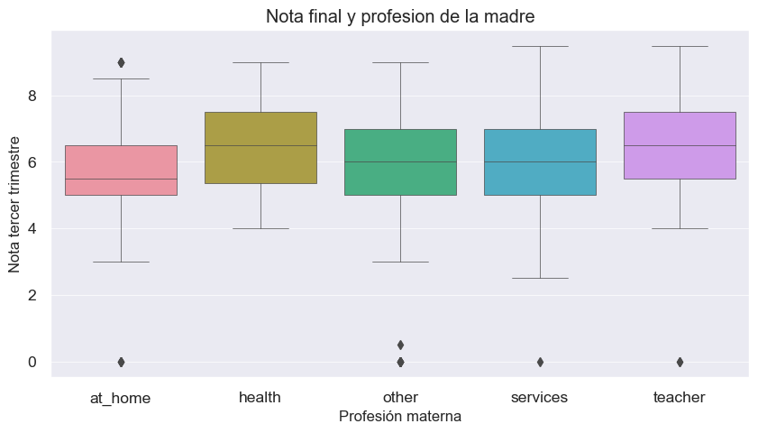

```python
# Profesion de la madre
plt.figure(figsize=(10,5))


g = sns.boxplot(
    x='Mjob',
    y='G3',
    data = estudiantes,
    linewidth=.5)

g.set_title('Nota final y profesion de la madre')
g.set_xlabel('Profesión materna')
g.set_ylabel('Nota tercer trimestre');
```

Para el caso de las madres, también se percibe que las notas medias son algo superiores que al resto de grupos, aunque el efecto no es tan acusado como para el caso de la profesion paterna

## Conclusiones

De los datos analizados procedentes de la encuesta al alumnado, se pueden sacar las siguientes conclusiones:

1. El consumo de alcohol afecta netativamente al rendimiento estudiantil.
2. Aquellos alumnos que están en una relación tienen calificaciones medias inferiores a los solteros.
3. No hay diferencias significativas en las distribuciones de notas para cada sexo.
4. Aunque las horas de estudio semanales afectan a la nota media, existen otros factores que también parecen contribuir a la mejora del rendimiento, como el hecho de que el padre o madre del alumno sea profesor.

## Referencias

A continuación un listado de la infromación consultada par hacer esta práctica:

- Página web de seaborn [Ploting with categorical data](https://seaborn.pydata.org/tutorial/categorical.html)
- Kaggle:
  - Dataset: [Student Alcohol Consumption](https://www.kaggle.com/uciml/student-alcohol-consumption)
  - Notebook: [What is the secret of academic success?](https://www.kaggle.com/hely333/what-is-the-secret-of-academic-success)
- Towards Data Science: [Making plots in jupyter notebook more meaninfull](https://towardsdatascience.com/making-plots-in-jupyter-notebook-beautiful-more-meaningful-23c8a35c0d5d)
- Medium: [5 tricks to make plots look better](https://medium.com/@andykashyap/top-5-tricks-to-make-plots-look-better-9f6e687c1e08)
- Datacamp: [Introduction to Data Visualization with Seaborn](https://learn.datacamp.com/courses/introduction-to-data-visualization-with-seaborn)